# chap5_scatter_plots

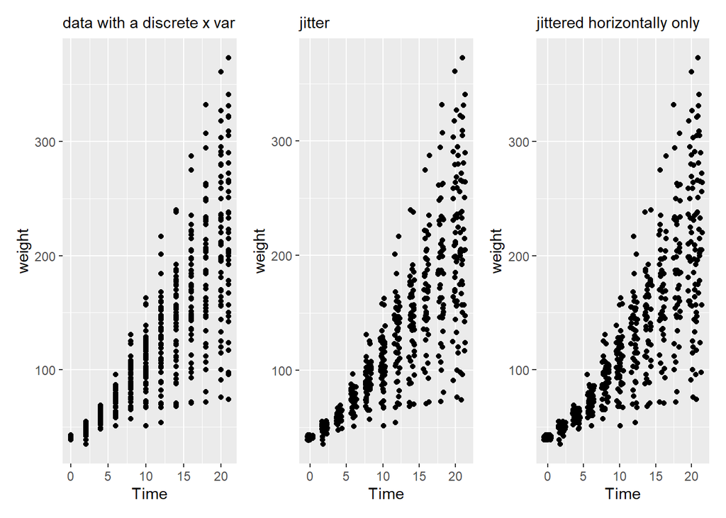

```r
sp1 <- ggplot(ChickWeight, aes(x = Time, y = weight))

fig5161 <-
  sp1 + geom_point() +
  labs(subtitle = "data with a discrete x var")

fig5162 <-
  sp1 + geom_jitter() +
  labs(subtitle = "jitter")

fig5163 <-
  sp1 + geom_jitter(width = 0.5, height = 0) +
  labs(subtitle = "jittered horizontally only")

fig5161 + fig5162 + fig5163
```

데이터가 하나만 이산형일 경우에는 box plot을 그리는 것이 더 좋다.  
`ChickWeights`data에서 x축은 개념적으로는 이산형인데 저장된 데이터는 숫자형이다.  
그래서 ggplot()은 각 박스가 어느 그룹인지 알지 못하기 때문에 `aes(group =...)`으로 정해주지 않으면 그래프를 그리지 못한다.

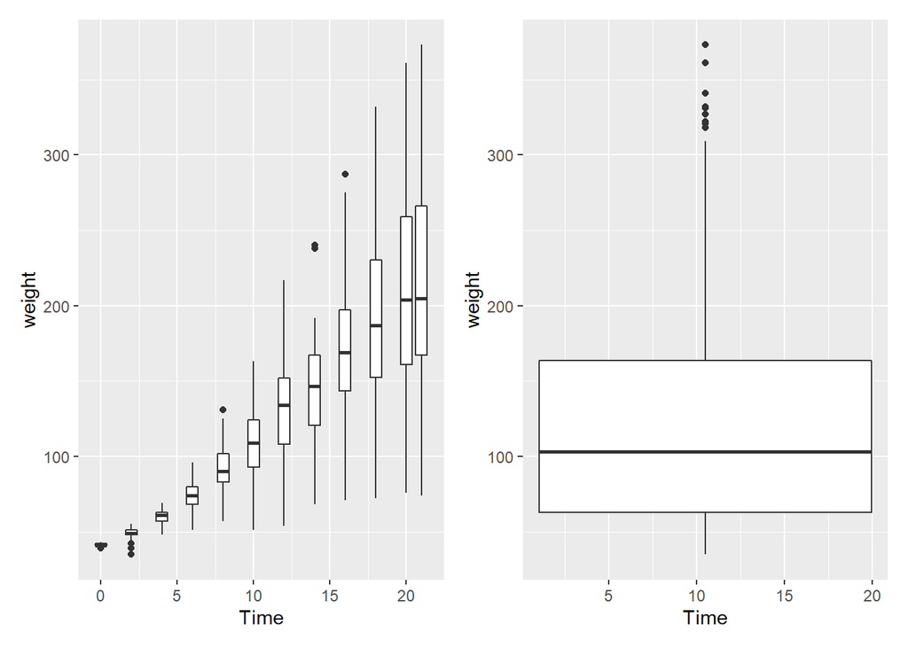

```r
fig5171 <-
  sp1 + geom_boxplot(aes(group = Time))

fig5172 <-
  sp1 + geom_boxplot()

fig5171 + fig5172
```

### 5.6 Adding fitted regression model lines

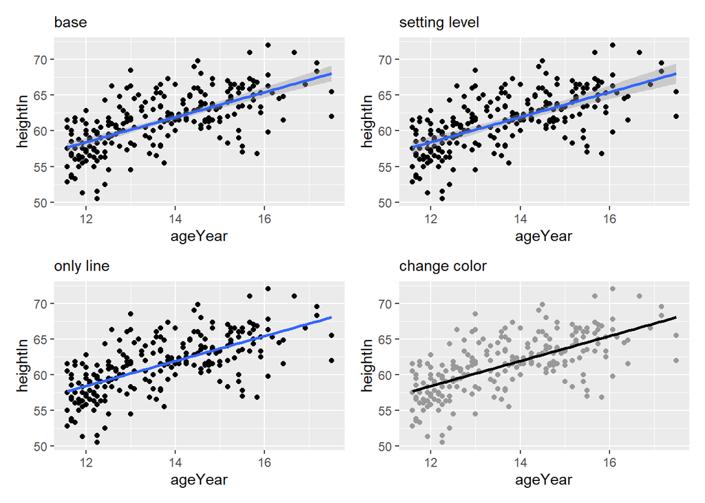

```r
fig518 <- ggplot(heightweight, aes(x = ageYear, y = heightIn))

fig5181 <-
  fig518 +
  geom_point() +
  geom_smooth(method = lm) +
  labs(subtitle = "base")

fig5182 <-
  fig518 +
  geom_point() +
  geom_smooth(method = lm, level = 0.99) +
  labs(subtitle = "setting level")

fig5183 <-
  fig518 +
  geom_point() +
  geom_smooth(method = lm, se = FALSE) +
  labs(subtitle = "only line")

fig5184 <-
  fig518 +
  geom_point(color = "gray60") +
  geom_smooth(method = lm, se = FALSE, color = "#000000") +
  labs(subtitle = "change color")

fig5181 + fig5182 + fig5183 + fig5184 + plot_layout(ncol = 2)
```

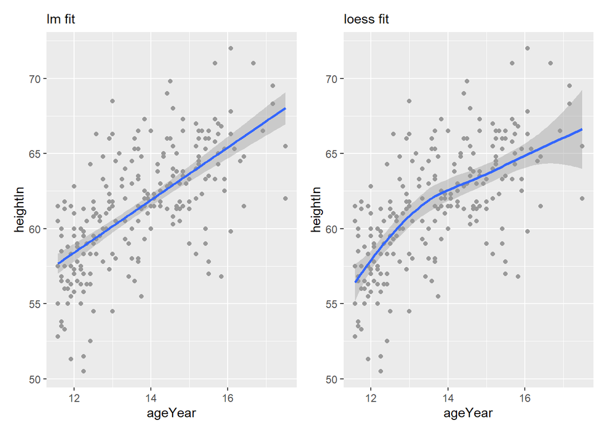

```r
fig5191 <-
  fig518 +
  geom_point(color = "gray60") +
  geom_smooth(method = lm) +
  labs(subtitle = "lm fit")

fig5192 <-
  fig518 +
  geom_point(color = "gray60") +
  geom_smooth(method = loess) +
  labs(subtitle = "loess fit")

fig5191 + fig5192
```

Logistic regression model fit에도 사용할 수 있음.  
`MASS` library에 있는 `biopsy`data를 사용해서 예제를 만들어 봄.

```r
library(MASS)
biopsy
```

```
##           ID V1 V2 V3 V4 V5 V6 V7 V8 V9     class
## 1    1000025  5  1  1  1  2  1  3  1  1    benign
## 2    1002945  5  4  4  5  7 10  3  2  1    benign
## 3    1015425  3  1  1  1  2  2  3  1  1    benign
## 4    1016277  6  8  8  1  3  4  3  7  1    benign
## 5    1017023  4  1  1  3  2  1  3  1  1    benign
## 6    1017122  8 10 10  8  7 10  9  7  1 malignant
## 7    1018099  1  1  1  1  2 10  3  1  1    benign
## 8    1018561  2  1  2  1  2  1  3  1  1    benign
## 9    1033078  2  1  1  1  2  1  1  1  5    benign
## 10   1033078  4  2  1  1  2  1  2  1  1    benign
## 11   1035283  1  1  1  1  1  1  3  1  1    benign
## 12   1036172  2  1  1  1  2  1  2  1  1    benign
## 13   1041801  5  3  3  3  2  3  4  4  1 malignant
## 14   1043999  1  1  1  1  2  3  3  1  1    benign
```

[output cut: 685 more lines]

```r
b <-
  biopsy %>%
  mutate(classn = case_when(class == "benign" ~ 0, TRUE ~ 1))

b
```

```
##           ID V1 V2 V3 V4 V5 V6 V7 V8 V9     class classn
## 1    1000025  5  1  1  1  2  1  3  1  1    benign      0
## 2    1002945  5  4  4  5  7 10  3  2  1    benign      0
## 3    1015425  3  1  1  1  2  2  3  1  1    benign      0
## 4    1016277  6  8  8  1  3  4  3  7  1    benign      0
## 5    1017023  4  1  1  3  2  1  3  1  1    benign      0
## 6    1017122  8 10 10  8  7 10  9  7  1 malignant      1
## 7    1018099  1  1  1  1  2 10  3  1  1    benign      0
## 8    1018561  2  1  2  1  2  1  3  1  1    benign      0
## 9    1033078  2  1  1  1  2  1  1  1  5    benign      0
## 10   1033078  4  2  1  1  2  1  2  1  1    benign      0
## 11   1035283  1  1  1  1  1  1  3  1  1    benign      0
## 12   1036172  2  1  1  1  2  1  2  1  1    benign      0
## 13   1041801  5  3  3  3  2  3  4  4  1 malignant      1
## 14   1043999  1  1  1  1  2  3  3  1  1    benign      0
```

[output cut: 685 more lines]

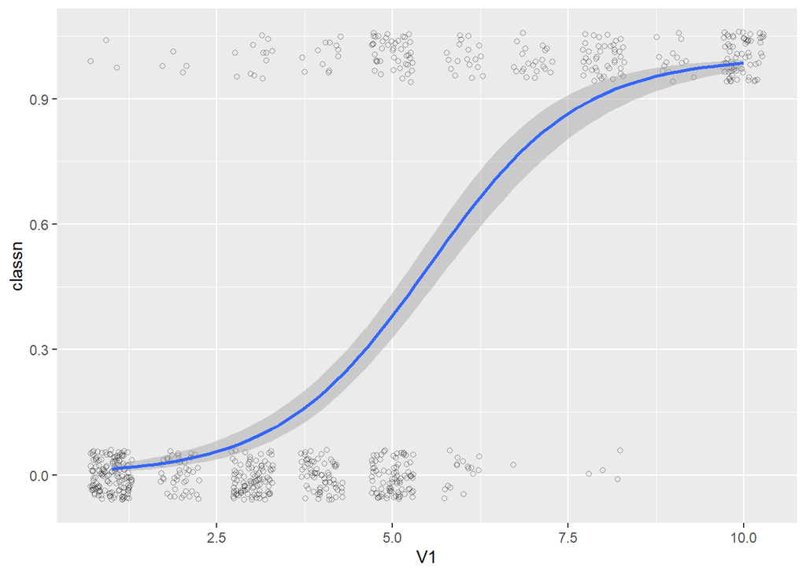

```r
b %>%
  ggplot(aes(x = V1, y = classn)) +
  geom_jitter(width = 0.3, height = 0.06, alpha = 0.4, shape = 21) +
  geom_smooth(method = "glm",
              method.args = list(family= binomial))
```

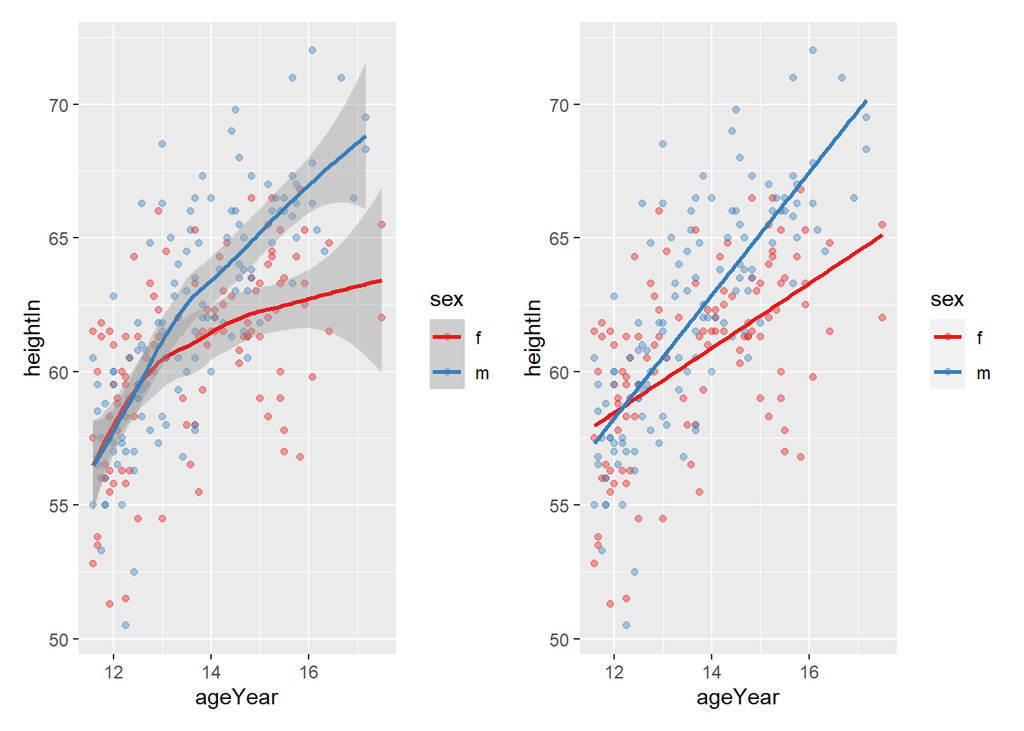

```r
sps1 <-
  heightweight %>%
  ggplot(aes(x = ageYear, y = heightIn, color = sex)) +
  geom_point(alpha = 0.4) +
  scale_color_brewer(palette = "Set1") +
  geom_smooth()

sps2 <-
  heightweight %>%
  ggplot(aes(x = ageYear, y = heightIn, color = sex)) +
  geom_point(alpha = 0.4) +
  scale_color_brewer(palette = "Set1") +
  geom_smooth(method = lm, se = FALSE)

sps1 + sps2
```

### 5.7 Adding fitted lines from an existing model

보통 fitted model을 만드는 가장 간단한 방법은 `stat_smooth()`를 사용하는 것이다.  
하지만 때로는 우리가 만든 fitted model를 그래프에 넣어야 할 때도 있다. 이는 우리가 만든 fitted model이 제대로 되었는지 확인하기에 좋은 방법이다.

```r
model <-
  lm(
    formula = heightIn ~ ageYear + I(ageYear^2),
    data = heightweight
  )

model
```

```
##
## Call:
## lm(formula = heightIn ~ ageYear + I(ageYear^2), data = heightweight)
##
## Coefficients:
##  (Intercept)       ageYear  I(ageYear^2)
##     -10.3136        8.6673       -0.2478
```

```r
# Create a data frame with ageYear column, interpolating across range
xmin <- min(heightweight$ageYear)
xmax <- max(heightweight$ageYear)
predicted <- data.frame(ageYear = seq(xmin, xmax, length.out = 100))

# Calculated predicted values of heightIn
predicted$heightIn <- predict(model, predicted)

predicted
```

```
##      ageYear heightIn
## 1   11.58000 56.82624
## 2   11.63980 57.00047
## 3   11.69960 57.17294
## 4   11.75939 57.34363
## 5   11.81919 57.51255
## 6   11.87899 57.67969
## 7   11.93879 57.84507
## 8   11.99859 58.00867
## 9   12.05838 58.17051
## 10  12.11818 58.33056
## 11  12.17798 58.48885
## 12  12.23778 58.64537
## 13  12.29758 58.80011
## 14  12.35737 58.95308
```

[output cut: 86 more lines]

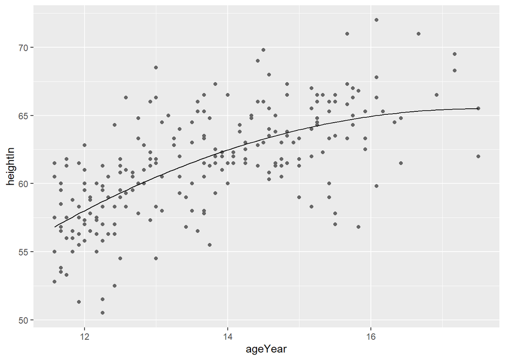

```r
heightweight %>%
  ggplot(aes(x = ageYear, y = heightIn)) +
  geom_point(color = "gray40")+
  geom_line(data = predicted)
```

`predictvals()`함수를 만들어 모델로부터 선을 추가하는 일을 간단하게 할 수 있게 만든다.  
앞서 한 것처럼 변수명을 찾아서 예측변수의 범위를 정하고 예측변수와 예측값을 데이터 프레임으로 반환한다는 것을 간단하게 해 주는 함수이다.  
함수가 반환한 데이터는 `geom_line()`에 넣으면 된다.

```r
# Given a model, predict values of yvar from xvar
# This supports one predictor and one predicted variable
# xrange: If NULL, determine the x range from the model object. If a vector with
#         two numbers, use those as the min and max of the prediction range.
# samples: Number of samples across the x range.
# ...: Further argument to be passed to predict()
predictvals <- function(model, xvar, yvar, xrange = NULL, samples = 100, ...) {

  # If xrange isn't passed in, determine xrange from the models.
  # Different ways of extracting the x range, depending on model type
  if(is.null(xrange)) {
    if(any(class(model) %in% c("lm", "glm")))
      xrange <- range(model$model[[xvar]])
    else if(any(class(model) %in% c("loess")))
      xrange <- range(model$x)
  }

  newdata <- data.frame(x = seq(xrange[1], xrange[2], length.out = samples))
  names(newdata) <- xvar
  newdata[[yvar]] <- predict(model, newdata = newdata, ...)
  newdata
}
```

```r
modlinear <- lm(heightIn ~ ageYear, heightweight)
modlinear
```

```
##
## Call:
## lm(formula = heightIn ~ ageYear, data = heightweight)
##
## Coefficients:
## (Intercept)      ageYear
##      37.436        1.748
```

```r
modloess <- loess(heightIn ~ ageYear, heightweight)
modloess
```

```
## Call:
## loess(formula = heightIn ~ ageYear, data = heightweight)
##
## Number of Observations: 236
## Equivalent Number of Parameters: 4.57
## Residual Standard Error: 2.949
```

```r
lm_predicted <- predictvals(modlinear, "ageYear", "heightIn")
lm_predicted
```

```
##      ageYear heightIn
## 1   11.58000 57.68034
## 2   11.63980 57.78488
## 3   11.69960 57.88942
## 4   11.75939 57.99397
## 5   11.81919 58.09851
## 6   11.87899 58.20305
## 7   11.93879 58.30759
## 8   11.99859 58.41213
## 9   12.05838 58.51668
## 10  12.11818 58.62122
## 11  12.17798 58.72576
## 12  12.23778 58.83030
## 13  12.29758 58.93484
## 14  12.35737 59.03939
```

[output cut: 86 more lines]

```r
loess_predicted <- predictvals(modloess, "ageYear", "heightIn")
loess_predicted
```

```
##      ageYear heightIn
## 1   11.58000 56.40981
## 2   11.63980 56.63254
## 3   11.69960 56.85157
## 4   11.75939 57.06738
## 5   11.81919 57.28048
## 6   11.87899 57.49133
## 7   11.93879 57.70038
## 8   11.99859 57.90689
## 9   12.05838 58.11036
## 10  12.11818 58.31055
## 11  12.17798 58.50725
## 12  12.23778 58.70023
## 13  12.29758 58.88926
## 14  12.35737 59.07436
```

[output cut: 86 more lines]

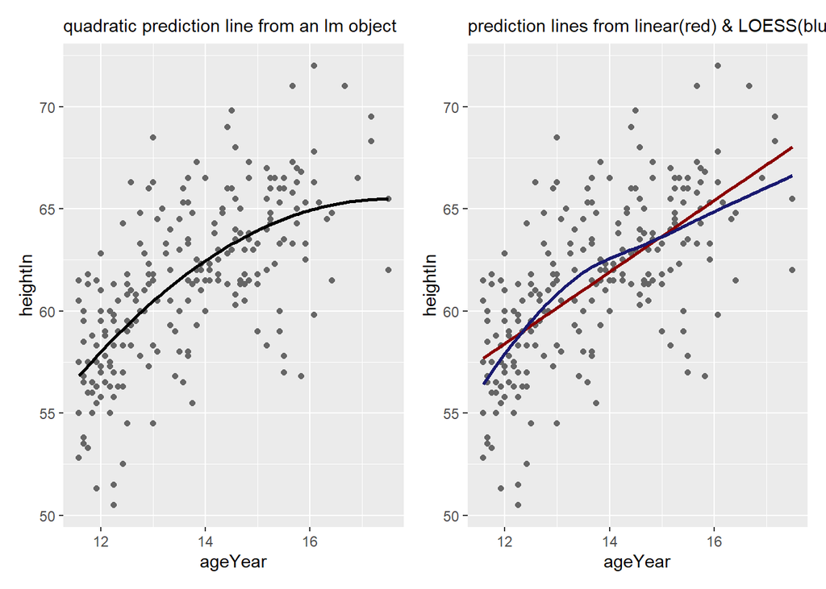

```r
fig5221 <-
  heightweight %>%
  ggplot(aes(x = ageYear, y = heightIn)) +
  geom_point(color = "gray40")+
  geom_line(data = predicted, size = 1) +
  labs(subtitle = "quadratic prediction line from an lm object")

fig5222 <-
  heightweight %>%
  ggplot(aes(x = ageYear, y = heightIn)) +
  geom_point(color = "gray40") +
  geom_line(data = lm_predicted, color = "#8B0000", size = 1) +
  geom_line(data = loess_predicted, color = "#191970", size = 1) +
  labs(subtitle = "prediction lines from linear(red) & LOESS(blue) model")

fig5221 + fig5222
```

만든 `predictvals()`를 logistic regression에도 적용해 본다.

```r
fitlogistic <- glm(classn ~ V1, b, family = binomial)

fitlogistic
```

```
##
## Call:  glm(formula = classn ~ V1, family = binomial, data = b)
##
## Coefficients:
## (Intercept)           V1
##     -5.1602       0.9355
##
## Degrees of Freedom: 698 Total (i.e. Null);  697 Residual
## Null Deviance:       900.5
## Residual Deviance: 464.1     AIC: 468.1
```

```r
glm_predicted <- predictvals(fitlogistic, "V1", "classn", type = "response")

glm_predicted
```

```
##            V1     classn
## 1    1.000000 0.01441866
## 2    1.090909 0.01567843
## 3    1.181818 0.01704637
## 4    1.272727 0.01853141
## 5    1.363636 0.02014317
## 6    1.454545 0.02189198
## 7    1.545455 0.02378895
## 8    1.636364 0.02584594
## 9    1.727273 0.02807568
## 10   1.818182 0.03049176
## 11   1.909091 0.03310867
## 12   2.000000 0.03594186
## 13   2.090909 0.03900770
## 14   2.181818 0.04232358
```

[output cut: 86 more lines]

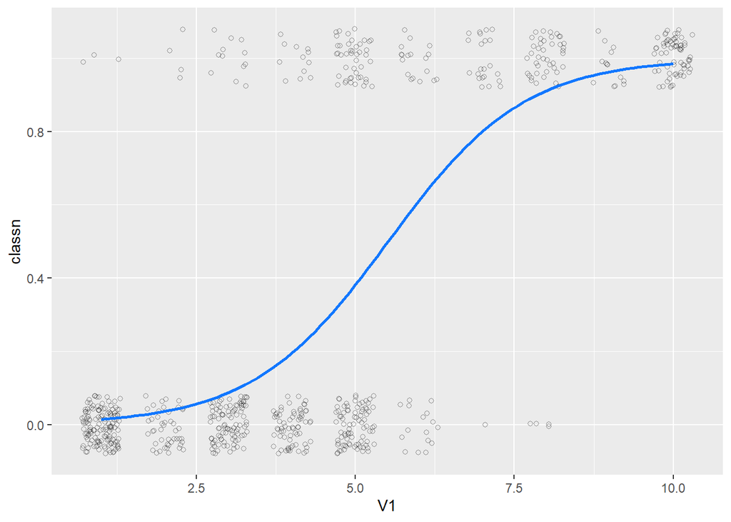

```r
b %>%
  ggplot(aes(x = V1, y = classn)) +
  geom_jitter(width = 0.3, height = 0.08, alpha = 0.4, shape = 21) +
  geom_line(data = glm_predicted, color = "#1177FF", size = 1)
```

### 5.8 Adding fitted lines from multiple existing model

```r
make_model <- function(data) {
  lm(heightIn ~ ageYear, data)
}
```

```r
library(plyr)
models <-
  heightweight %>%
  dlply("sex", .fun = make_model)

models
```

```
## $f
##
## Call:
## lm(formula = heightIn ~ ageYear, data = data)
##
## Coefficients:
## (Intercept)      ageYear
##      43.963        1.209
##
##
## $m
##
## Call:
## lm(formula = heightIn ~ ageYear, data = data)
##
## Coefficients:
## (Intercept)      ageYear
##      30.658        2.301
##
##
## attr(,"split_type")
## [1] "data.frame"
## attr(,"split_labels")
##   sex
## 1   f
## 2   m
```

```r
predvals <- ldply(models, .fun = predictvals, xvar = "ageYear", yvar="heightIn")

predvals
```

```
##     sex  ageYear heightIn
## 1     f 11.58000 57.96250
## 2     f 11.63980 58.03478
## 3     f 11.69960 58.10707
## 4     f 11.75939 58.17936
## 5     f 11.81919 58.25165
## 6     f 11.87899 58.32394
## 7     f 11.93879 58.39623
## 8     f 11.99859 58.46852
## 9     f 12.05838 58.54081
## 10    f 12.11818 58.61310
## 11    f 12.17798 58.68539
## 12    f 12.23778 58.75768
## 13    f 12.29758 58.82997
## 14    f 12.35737 58.90226
```

[output cut: 186 more lines]

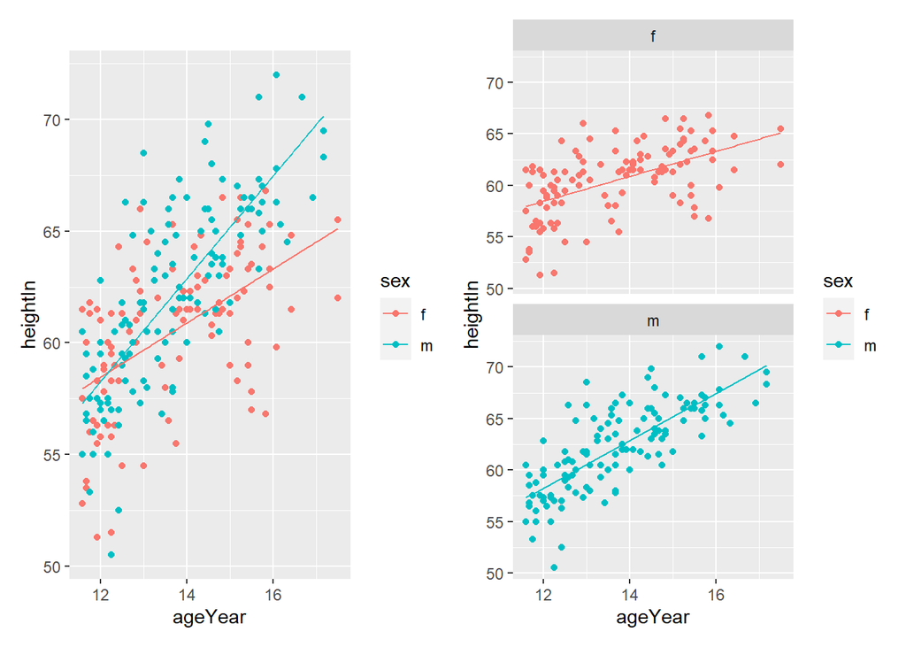

```r
fig_5241 <-
heightweight %>%
  ggplot(aes(x = ageYear, y = heightIn, color = sex)) +
  geom_point() +
  geom_line(data = predvals)

fig_5242 <-
heightweight %>%
  ggplot(aes(x = ageYear, y = heightIn, color = sex)) +
  geom_point() +
  geom_line(data = predvals) +
  facet_wrap(~sex, ncol = 1)

fig_5241 + fig_5242
```

```r
predvals <- ldply(models, .fun = predictvals,
                  xvar = "ageYear", yvar = "heightIn",
                  xrange = range(heightweight$ageYear))
predvals
```

```
##     sex  ageYear heightIn
## 1     f 11.58000 57.96250
## 2     f 11.63980 58.03478
## 3     f 11.69960 58.10707
## 4     f 11.75939 58.17936
## 5     f 11.81919 58.25165
## 6     f 11.87899 58.32394
## 7     f 11.93879 58.39623
## 8     f 11.99859 58.46852
## 9     f 12.05838 58.54081
## 10    f 12.11818 58.61310
## 11    f 12.17798 58.68539
## 12    f 12.23778 58.75768
## 13    f 12.29758 58.82997
## 14    f 12.35737 58.90226
```

[output cut: 186 more lines]

`predvals`를 계산할 때 xrange를 맞춰 male의 X축 range를 늘려 female과 동일하게 맞춤.

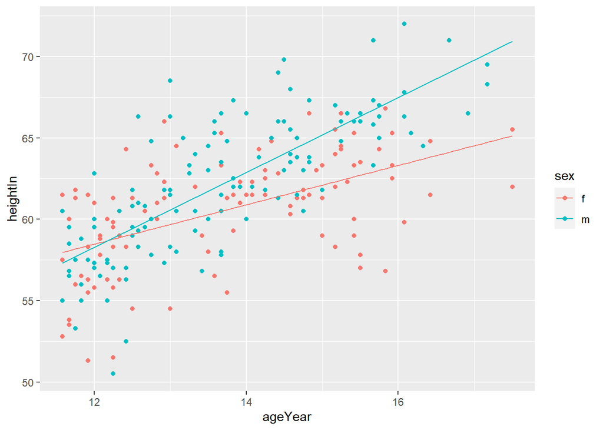

```r
heightweight %>%
  ggplot(aes(x = ageYear, y = heightIn, color = sex)) +
  geom_point() +
  geom_line(data = predvals)
```

### 5.9 Adding annotations with model coefficients

```r
model <- lm(heightIn ~ ageYear, heightweight)

summary(model)
```

```
##
## Call:
## lm(formula = heightIn ~ ageYear, data = heightweight)
##
## Residuals:
##     Min      1Q  Median      3Q     Max
## -8.3517 -1.9006  0.1378  1.9071  8.3371
##
## Coefficients:
##             Estimate Std. Error t value Pr(>|t|)
## (Intercept)  37.4356     1.8281   20.48   <2e-16 ***
## ageYear       1.7483     0.1329   13.15   <2e-16 ***
## ---
## Signif. codes:  0 '***' 0.001 '**' 0.01 '*' 0.05 '.' 0.1 ' ' 1
##
## Residual standard error: 2.989 on 234 degrees of freedom
## Multiple R-squared:  0.4249, Adjusted R-squared:  0.4225
## F-statistic: 172.9 on 1 and 234 DF,  p-value: < 2.2e-16
```

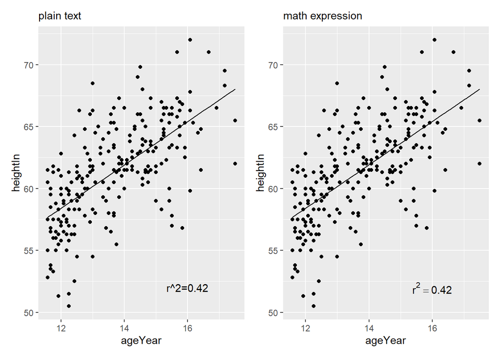

```r
pred <- predictvals(model, "ageYear", "heightIn")

fig5261 <-
  heightweight %>%
  ggplot(aes(x = ageYear, y = heightIn)) +
  geom_point() +
  geom_line(data = pred) +
  labs(subtitle = "plain text") +
  annotate("text", label = "r^2=0.42", x = 16, y = 52)

fig5262 <-
  heightweight %>%
  ggplot(aes(x = ageYear, y = heightIn)) +
  geom_point() +
  geom_line(data = pred) +
  labs(subtitle = "math expression") +
  annotate("text", label = "r^2==0.42", parse = TRUE, x = 16, y = 52)

fig5261 + fig5262
```

```r
eqn <-
  as.character(as.expression(
    substitute(italic(y) == a + b * italic(x) * "," ~~ italic(r)^2 ~ "=" ~ r2,
               list(a = format(coef(model)[1], digits = 3),
                    b = format(coef(model)[2], digits = 3),
                    r2 = format(summary(model)$r.squared, digits = 2)))
  ))

eqn
```

```
## [1] "italic(y) == c(`(Intercept)` = \"37.4\") + c(ageYear = \"1.75\") * italic(x) * \",\" ~ ~italic(r)^2 ~ \"=\" ~ \"0.42\""
```

```r
parse(text = eqn)
```

```
## expression(italic(y) == c(`(Intercept)` = "37.4") + c(ageYear = "1.75") *
##     italic(x) * "," ~ ~italic(r)^2 ~ "=" ~ "0.42")
```

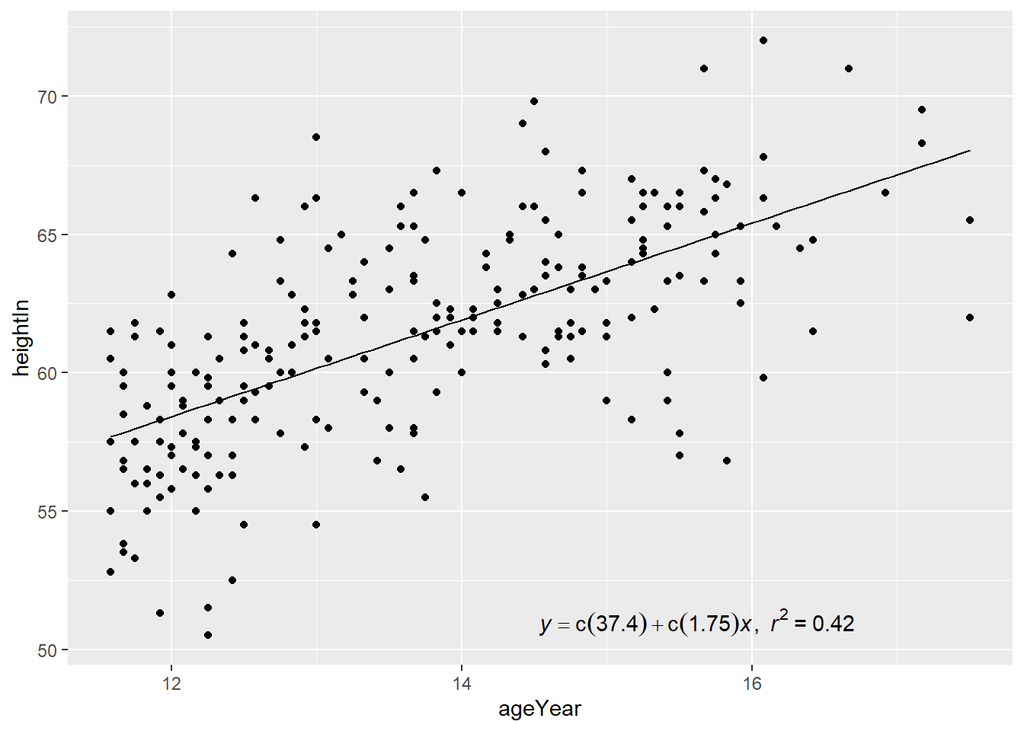

```r
heightweight %>%
  ggplot(aes(x = ageYear, y = heightIn)) +
  geom_point() +
  geom_line(data = pred) +
  annotate("text", label = eqn, parse=TRUE, x = Inf, y = -Inf,
           vjust = -1, hjust = 1.5)
```

### 5.10 Adding marginal rugs to a scatter plot

```r
faithful
```

```
##     eruptions waiting
## 1       3.600      79
## 2       1.800      54
## 3       3.333      74
## 4       2.283      62
## 5       4.533      85
## 6       2.883      55
## 7       4.700      88
## 8       3.600      85
## 9       1.950      51
## 10      4.350      85
## 11      1.833      54
## 12      3.917      84
## 13      4.200      78
## 14      1.750      47
```

[output cut: 258 more lines]

marginal rug plot을 그리기 위해서는 1차원 scatter plot이 필수적이다.  
marginal rug가 크게 효과적이지 않은 data set도 있다.  
아래 예시에서는 rug line이 overplotting된 곳이 많아 이를 해결하기 위해서는 `geom_rug()`에 jitter 속성을 사용하는 것도 하나의 방법이다.

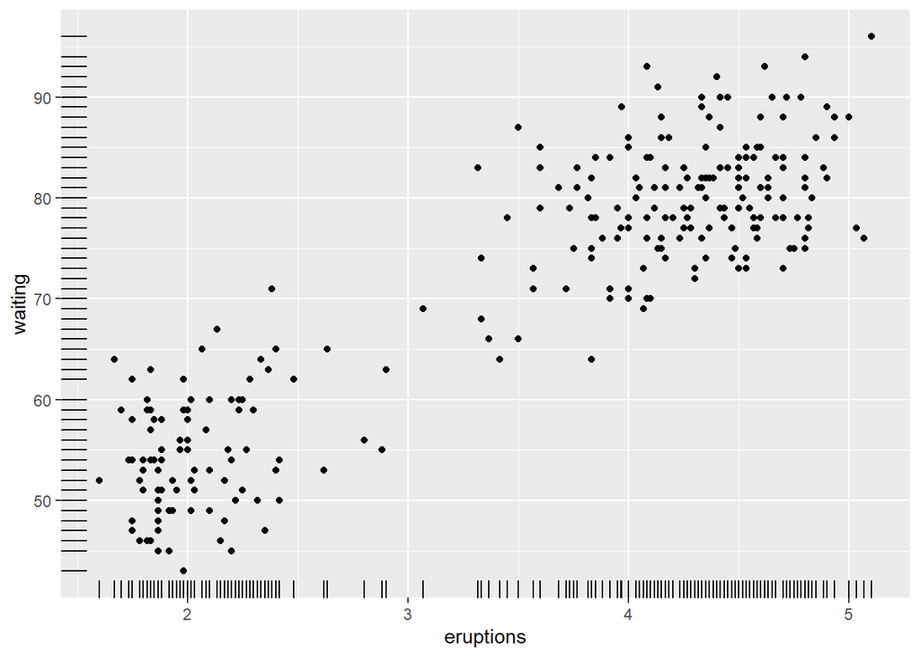

```r
faithful %>%
  ggplot(aes(x = eruptions, y = waiting)) +
  geom_point() +
  geom_rug()
```

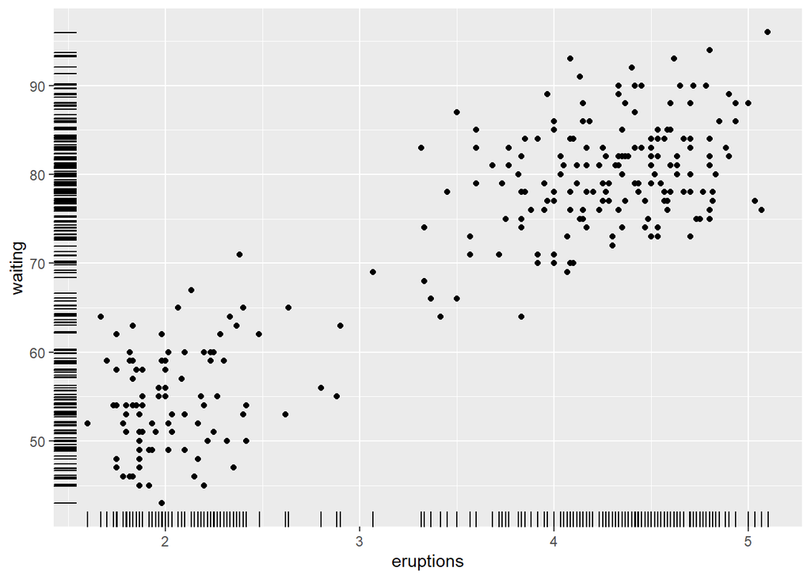

```r
faithful %>%
  ggplot(aes(x = eruptions, y = waiting)) +
  geom_point() +
  geom_rug(position = "jitter")
```

### 5.11 Labeling points in a scatter plot

주석을 붙일 텍스트가 한두개 정도면 `annotate()`를 사용하면 되지만, 많은 수의 label을 붙여야 한다면 각 label의 위치를 일일이 조정하면서 넣을 수가 없기 때문에 `geom_text()`를 써서 한 번에 label을 출력하도록 한다.

```r
countries
```

```
##                                 Name Code Year          GDP laborrate
## 1                        Afghanistan  AFG 1960     55.60700        NA
## 2                        Afghanistan  AFG 1961     55.66865        NA
## 3                        Afghanistan  AFG 1962     54.35964        NA
## 4                        Afghanistan  AFG 1963     73.19877        NA
## 5                        Afghanistan  AFG 1964     76.37303        NA
## 6                        Afghanistan  AFG 1965     94.09873        NA
## 7                        Afghanistan  AFG 1966    128.11451        NA
## 8                        Afghanistan  AFG 1967    149.89117        NA
## 9                        Afghanistan  AFG 1968    120.35148        NA
## 10                       Afghanistan  AFG 1969    120.65515        NA
## 11                       Afghanistan  AFG 1970    146.16802        NA
## 12                       Afghanistan  AFG 1971    149.19693        NA
## 13                       Afghanistan  AFG 1972    126.69486        NA
## 14                       Afghanistan  AFG 1973    134.20568        NA
```

[output cut: 22019 more lines]

```r
countries %>%
  subset(Year == 2009 & healthexp > 2000)
```

```
##                 Name Code Year       GDP laborrate healthexp infmortality
## 254          Andorra  AND 2009        NA        NA  3089.636          3.1
## 560        Australia  AUS 2009  42130.82      65.2  3867.429          4.2
## 611          Austria  AUT 2009  45555.43      60.4  5037.311          3.6
## 968          Belgium  BEL 2009  43640.20      53.5  5104.019          3.6
## 1733          Canada  CAN 2009  39599.04      67.8  4379.761          5.2
## 2702         Denmark  DNK 2009  55933.35      65.4  6272.729          3.4
## 3365         Finland  FIN 2009  44576.73      60.9  4309.604          2.5
## 3416          France  FRA 2009  40663.05      56.1  4797.966          3.5
## 3671         Germany  DEU 2009  40658.58      59.8  4628.769          3.5
## 3824          Greece  GRC 2009  28936.48      53.7  3040.734          3.5
## 4436         Iceland  ISL 2009  37972.24      77.5  3130.391          1.7
## 4691         Ireland  IRL 2009  49737.93      63.6  4951.845          3.4
## 4844           Italy  ITA 2009  35073.32      49.1  3327.630          3.2
## 4946           Japan  JPN 2009  39456.44      59.5  3321.466          2.4
## 5864      Luxembourg  LUX 2009 106252.24      55.5  8182.855          2.2
## 6680          Monaco  MCO 2009 172676.34        NA  7137.390          3.4
## 7088     Netherlands  NLD 2009  48068.35      66.1  5163.740          3.8
## 7190     New Zealand  NZL 2009  29352.45      68.6  2633.625          4.9
## 7445          Norway  NOR 2009  78408.71      66.9  7661.610          2.9
## 7955        Portugal  PRT 2009  22029.87      62.5  2409.661          3.2
## 8312      San Marino  SMR 2009        NA        NA  4089.271          1.9
## 8822        Slovenia  SVN 2009  24101.26      58.9  2174.718          2.5
## 9077           Spain  ESP 2009  31891.39      58.6  3075.013          4.0
## 9536          Sweden  SWE 2009  43406.17      64.8  4251.976          2.4
## 9587     Switzerland  CHE 2009  63524.65      66.9  7140.729          4.1
## 10454 United Kingdom  GBR 2009  35163.41      62.2  3285.050          4.7
## 10505  United States  USA 2009  45744.56      65.0  7410.163          6.6
```

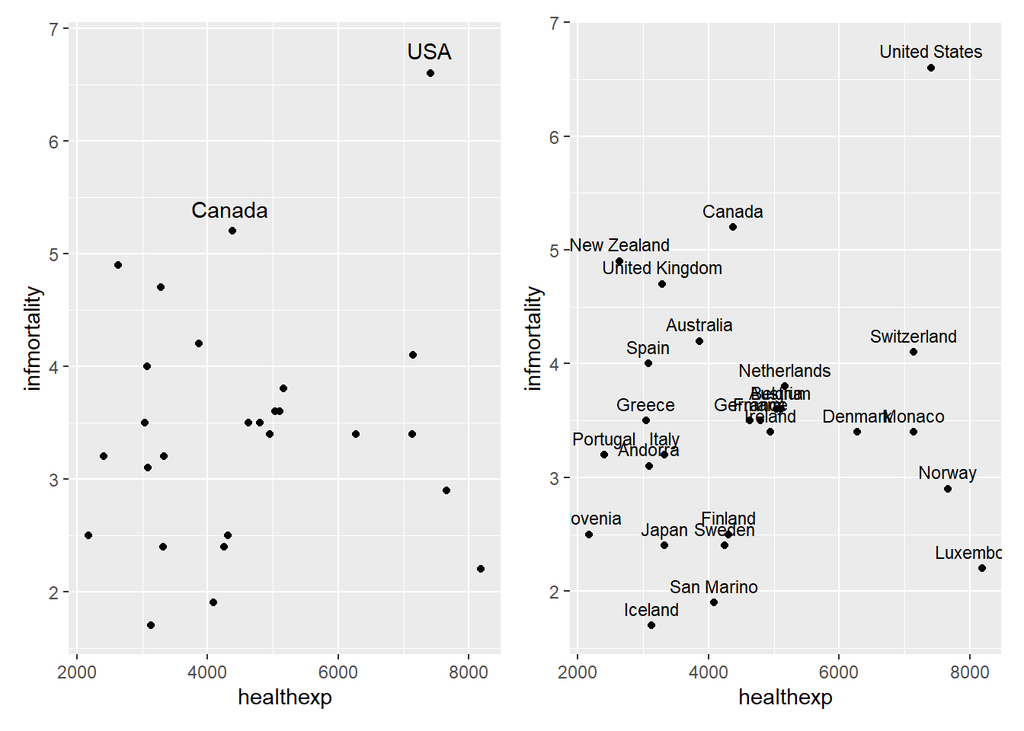

```r
fig530 <-
  countries %>%
  subset(Year == 2009 & healthexp > 2000) %>%
  ggplot(aes(x = healthexp, y = infmortality)) +
  geom_point()

fig5301 <-
  fig530 +
  annotate("text", x = 4350, y = 5.4, label = "Canada") +
  annotate("text", x = 7400, y = 6.8, label = "USA")

fig5302 <-
  fig530 +
  geom_text(aes(label = Name), nudge_y = 0.15, size = 3)

fig5301 + fig5302
```

**vjust=0**은 점과 같은 수준으로 각 글자의 baseline을 맞춘겠다는 뜻이고, **vjust=1**은 점과 글자의 위쪽을 맞춘다는 뜻이다.  
하지만 이것만으로 충분하지 않을 때는 y mapping값을 더하거나 빼는 방법으로 같은 효과를 만들어 낼 수 있다.

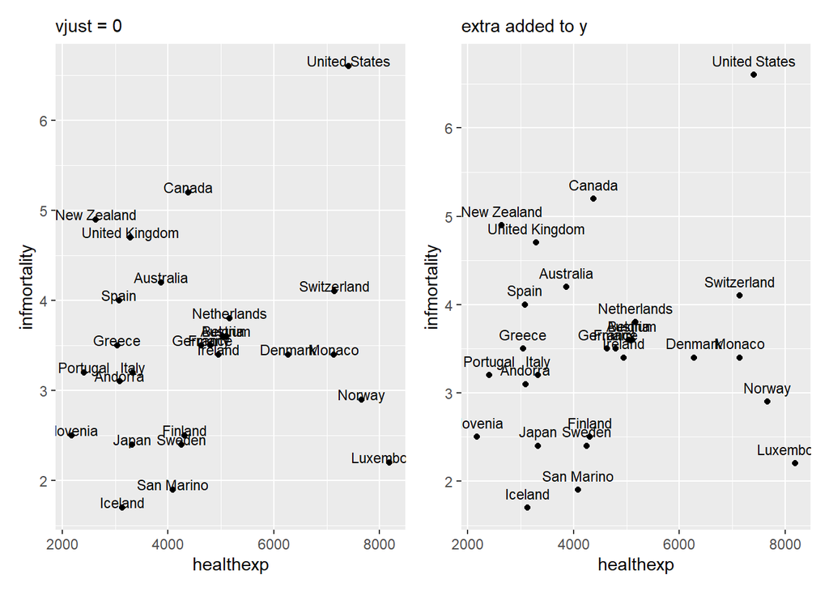

```r
fig5311 <-
  fig530 +
  geom_text(aes(label = Name), size = 3, vjust = 0) +
  labs(subtitle = "vjust = 0")

fig5312 <-
  fig530 +
  geom_text(aes(y = infmortality+0.1, label=Name),
            size = 3, vjust = 0)+
  labs(subtitle = "extra added to y")

fig5311 + fig5312
```